# Quel est le profil des clients Aramisauto ?

# 1 Introduction

Le marché automobile connaît depuis plusieurs années une transformation profonde. D’une part, le parcours d’achat est devenu fortement digitalisé : recherche produit, comparaison, simulation de financement et prise de contact s’effectuent désormais largement en ligne. D’autre part, la transition énergétique recompose progressivement la structure de l’offre, avec la montée de l’hybride et de l’électrique.

Dans ce contexte, la connaissance fine des profils clients devient un levier stratégique pour un acteur comme **Aramisauto**, leader de la vente de véhicules d’occasion en ligne. Comprendre qui achète, comment les clients naviguent, quels types de véhicules ils choisissent, s’ils financent ou non leur achat, et dans quels territoires ils se situent, permet d’orienter plus efficacement les actions marketing et commerciales.

L’objectif de ce projet est de répondre à la question centrale suivante :

> **Quel est le profil des clients Aramisauto ?**

Pour y répondre, nous avons mobilisé une démarche complète de datamining fondée sur :

- l’analyse de plusieurs tables internes,
- l’enrichissement par des données externes issues de l’INSEE et du SDES,
- la création de variables analytiques,
- une segmentation non supervisée par **K-means**,
- et une traduction des résultats en recommandations directement actionnables.

Ce rapport ne se limite pas à une description statistique. Il vise à relier les résultats quantitatifs à une lecture métier : quels segments concentrent la valeur, quels profils sont sensibles au financement, quels clients sont les plus digitaux, et quelles actions marketing peuvent être priorisées.

# 2 Contexte et objectifs

## 2.1 Contexte du projet

Aramisauto évolue sur un marché à la fois concurrentiel et mouvant. La vente de véhicules d’occasion en ligne exige de concilier plusieurs dimensions : la confiance, la lisibilité de l’offre, la qualité de l’accompagnement, la personnalisation du parcours et la capacité à répondre à des attentes hétérogènes selon les clients.

Le projet s’inscrit donc dans une logique double :

- **mieux comprendre le portefeuille client existant**,
- **outiller la décision marketing** grâce à une segmentation robuste et lisible.

## 2.2 Objectifs de l’étude

Les objectifs principaux sont les suivants :

1. Décrire le profil global des clients Aramisauto ;
2. Identifier les principales caractéristiques des véhicules vendus ;
3. Étudier les comportements de navigation, de financement et de livraison ;
4. Construire une segmentation client interprétable ;
5. Comparer certaines tendances Aramisauto au marché automobile national ;
6. Proposer des recommandations marketing ciblées.

## 2.3 Périmètre temporel

Les données internes analysées couvrent plusieurs temporalités :

- **Leads clients créés** : 2012 à mai 2024 ;
- **Commandes et reprises** : janvier à mai 2024 ;
- **Navigation web** : décembre 2023 à mai 2024.

# 3 Description des données

## 3.1 Tables internes

Les données internes fournies par Aramisauto proviennent de six tables complémentaires.

| Table | Lignes | Colonnes | Description |
| --- | --- | --- | --- |
| table_client | 5 661 | 6 | Profil démographique des leads : âge, genre, localisation |
| table_commande_reprise | 5 561 | 7 | Commandes et reprises de véhicules (janvier à mai 2024) |
| table_vehicule | 4 217 | 13 | Catalogue véhicule : marque, énergie, catégorie, kilométrage |
| table_financement | 1 638 | 3 | Type de financement : LOA ou crédit |
| table_navigation_web | 361 252 | 10 | Événements de navigation sur aramisauto.com |
| table_nearest_agency | 6 014 | 4 | Distance et durée vers l’agence la plus proche |

## 3.2 Données externes

Afin d’enrichir l’analyse, plusieurs sources open data ont été mobilisées :

- **INSEE Filosofi 2021** : revenu médian par unité de consommation et par département ;
- **INSEE populations légales 2021** : données démographiques territoriales ;
- **SDES 2021–2024** : immatriculations de véhicules neufs par énergie.

L’enrichissement externe apporte une profondeur essentielle à l’analyse. Il permet de ne pas considérer les clients Aramisauto de manière isolée, mais de les replacer dans un contexte territorial, socio-économique et sectoriel plus large.

## 3.3 Schéma logique des jointures

La table d’analyse finale a été construite à partir des jointures suivantes :

- `table_client (ID_LEAD)` → `table_commande_reprise (LEAD_ID)`
- `table_commande_reprise (VEHICULE_ID)` → `table_vehicule (VEHICULE_ID)`
- `table_commande_reprise (LEAD_ID + VEHICULE_ID)` → `table_financement`
- `table_client (ID_LEAD)` → navigation web agrégée par lead
- `table_client (CODE_POSTAL)` → `table_nearest_agency (ZIP_CODE)`
- `table_client (NUM_DEPT)` → données INSEE départementales

# 4 Préparation des données

## 4.1 Nettoyage

La phase de préparation a consisté à fiabiliser la base avant toute modélisation.

Les principales opérations réalisées sont les suivantes :

- conversion des dates au bon format ;
- filtrage des âges aberrants ;
- nettoyage de certaines modalités textuelles invalides ;
- traitement des valeurs manquantes numériques par la médiane ;
- création du numéro de département à partir du code postal ;
- séparation des commandes et des reprises.

## 4.2 Feature engineering

Plusieurs variables dérivées ont été construites pour rendre l’analyse plus pertinente :

- `AGE`
- `VEHICULE_AGE_ANNEES`
- `NB_SESSIONS`
- `NB_PAGES_PRODUIT`
- `NB_PAGES_SEARCH`
- `AGENCE_DIST_KM`
- `A_FINANCEMENT`
- `A_REPRISE`
- `REVENU_MEDIAN_UC_2021`

Ces variables résument à la fois :

- le profil du client,
- l’intensité de son parcours digital,
- son rapport au financement,
- la proximité géographique,
- et le contexte socio-économique local.

# 5 Vue d’ensemble du portefeuille clients

La base étudiée permet de dresser un premier portrait synthétique du portefeuille clients Aramisauto.

**Clients acheteurs analysés :** 4 217

**Panier moyen :** 22 107 € | **Médiane :** 21 299 €

**Âge moyen :** 52 ans | **Médiane :** 51 ans

**Part de financement :** 39,5 %

**Marque n°1 :** Peugeot

**Taux de reprise :** 65,6 %

**Part des hommes :** 66 %

Ces premiers indicateurs montrent que le portefeuille étudié est structuré autour d’une clientèle plutôt mature, avec un panier moyen significatif, un recours non négligeable au financement et une présence importante des reprises. Cela suggère un marché où la transaction automobile est souvent pensée comme une opération complète, et non comme un simple achat isolé.

# 6 Analyse descriptive

## 6.1 Le catalogue véhicule

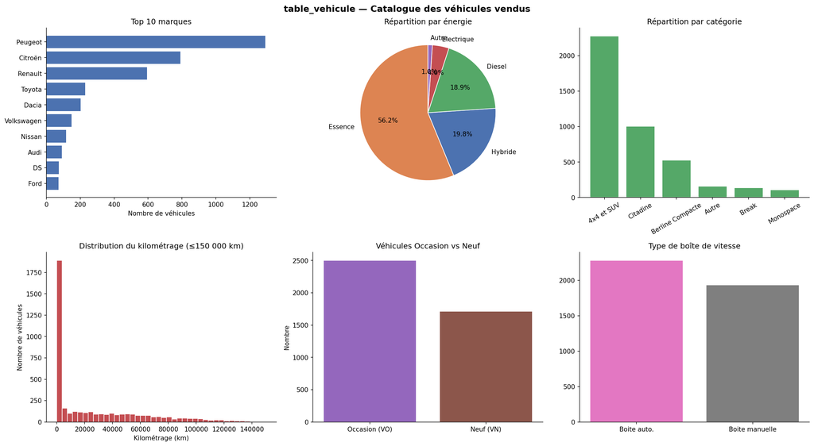

L’analyse du catalogue met en évidence plusieurs constats majeurs. D’abord, les marques françaises dominent clairement les ventes, avec **Peugeot**, **Citroën** et **Renault** en tête. Ensuite, la motorisation **essence** reste majoritaire, tandis que l’hybride occupe déjà une place significative. Enfin, les catégories les plus représentées sont les **SUV / 4x4** et les **citadines**.

Cette structure est cohérente avec le positionnement d’Aramisauto sur un marché de volume, adressé à une clientèle recherchant des véhicules polyvalents, familiers et adaptés à des usages quotidiens variés.

## 6.2 Profil démographique des leads

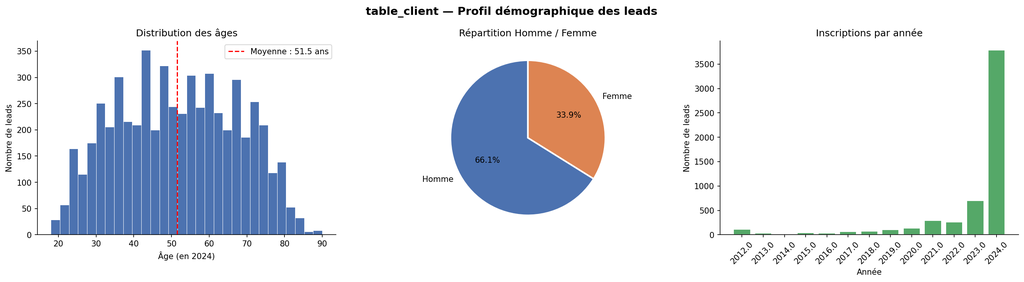

Le profil client met en évidence une distribution des âges centrée autour de la cinquantaine. La clientèle apparaît majoritairement masculine, même si la part féminine demeure substantielle. L’évolution des inscriptions suggère également une montée récente des leads, ce qui témoigne d’une dynamique d’acquisition soutenue.

Le point saillant ici est la maturité du portefeuille. Le client type Aramisauto n’est pas un acheteur très jeune ni un primo-accédant systématique. Il s’agit plus souvent d’un client installé, potentiellement plus solvable, dont l’achat s’inscrit dans une logique d’arbitrage entre confort, prix, confiance et simplicité.

## 6.3 Navigation web

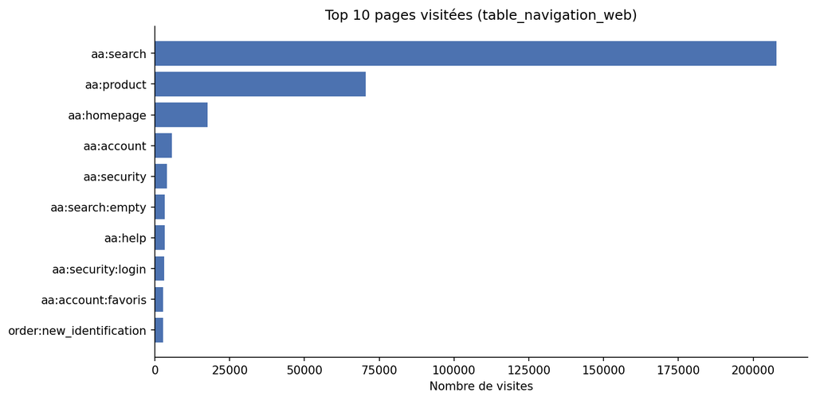

L’activité web est très fortement concentrée sur les pages de recherche, très loin devant les autres pages. Cela signifie que le moteur de recherche et les fiches produits constituent le cœur du parcours digital.

Cette observation est stratégique : si la recherche produit concentre l’attention, alors la qualité du filtrage, la pertinence des résultats, la lisibilité des informations et la personnalisation du parcours deviennent des leviers prioritaires de conversion.

# 7 Segmentation client par K-means

## 7.1 Choix de la méthode

La segmentation a été menée à l’aide de l’algorithme **K-means**, retenu pour plusieurs raisons :

- il s’adapte bien à des variables numériques standardisées ;
- il est rapide à exécuter ;
- il produit des segments lisibles ;
- il est particulièrement utile lorsqu’on cherche une restitution métier simple.

| Méthode | Type | Avantage_principal | Limitation | Retenue |
| --- | --- | --- | --- | --- |
| K-means | Non supervisé | Interprétable, rapide, scalable | Nombre de clusters à fixer | Oui |
| DBSCAN | Densité | Détecte les outliers | Sensible aux hyperparamètres | Non |
| Hiérarchique | Arborescent | Visualisation riche | Peu scalable | Non |
| GMM | Probabiliste | Clusters souples | Moins lisible métier | Non |
| RFM | Expert | Lecture business intuitive | Nécessite historique multi-périodes | Partiel |

## 7.2 Choix du nombre de clusters

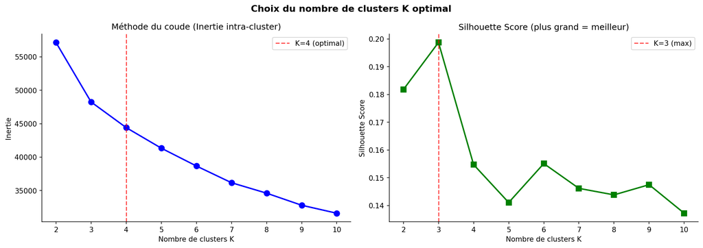

Le nombre optimal de clusters a été choisi à partir de la méthode du coude et du score de silhouette. Le compromis le plus satisfaisant est obtenu pour **K = 4**.

Cela permet d’avoir une segmentation :

- suffisamment fine pour distinguer des comportements différents,
- mais encore assez simple pour être utilisée par des équipes métier.

## 7.3 Visualisation des clusters

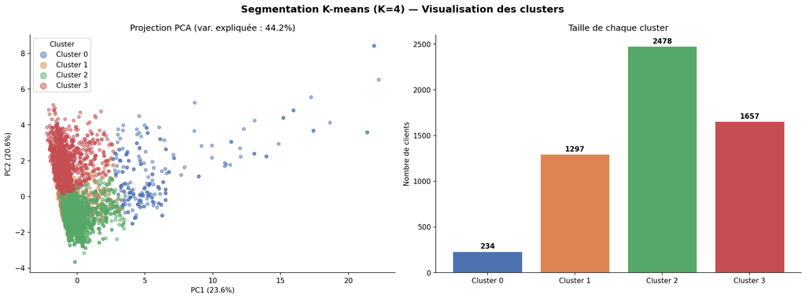

La projection PCA montre que les clusters ne sont pas totalement disjoints, ce qui est naturel dans des données clients réelles. Néanmoins, des formes distinctes apparaissent, traduisant des comportements suffisamment structurés pour justifier une segmentation exploitable.

## 7.4 Profil comparatif des segments

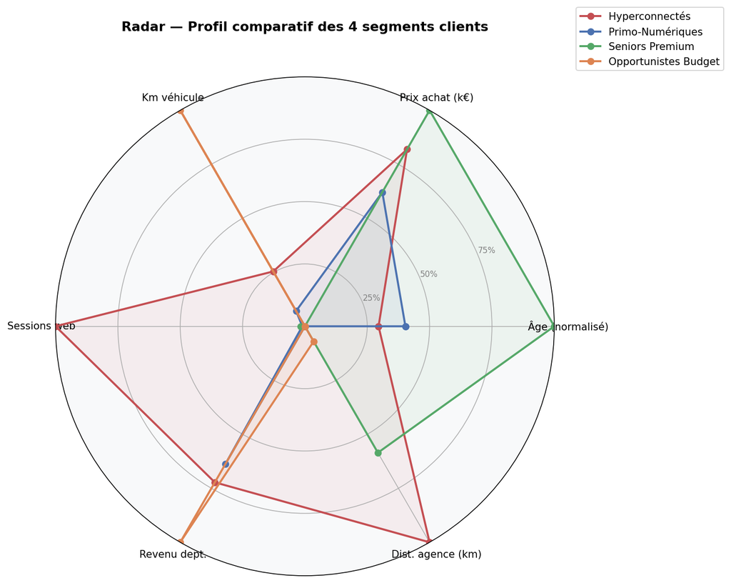

Le radar de comparaison met en évidence quatre profils distincts :

### 1. Seniors Premium

Ce segment est composé de clients plus âgés, avec les paniers moyens les plus élevés, et une appétence pour des véhicules récents ou quasi neufs. Leur activité web est relativement modérée. Ils représentent le cœur de valeur du portefeuille.

### 2. Opportunistes Budget

Ces clients sont plus sensibles au prix et s’orientent davantage vers des véhicules plus kilométrés. Ils recherchent avant tout un bon compromis économique. Ce segment est essentiel en volume.

### 3. Primo-Numériques

Ce groupe se caractérise par un usage digital correct, un intérêt pour les véhicules récents et un recours plus important au financement. Il représente un segment intermédiaire, avec un potentiel d’upsell.

### 4. Hyperconnectés

Ce segment, plus petit en taille, se distingue par une activité web très intense. Il correspond à des clients qui comparent beaucoup, consultent massivement l’offre et sont naturellement plus réceptifs aux logiques de personnalisation et de remarketing.

La segmentation fait apparaître une structure très lisible du portefeuille : un cœur de clientèle premium et mature, un segment prix très important en volume, un groupe intermédiaire sensible au financement, et une minorité ultra-digitale à forte valeur stratégique.

# 8 Analyse géographique

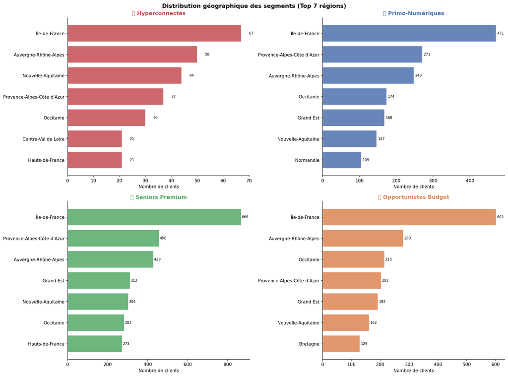

L’analyse territoriale montre une forte concentration des clients en **Île-de-France**, puis dans les grandes régions comme **Auvergne-Rhône-Alpes** et **Provence-Alpes-Côte d’Azur**. Cette géographie est cohérente avec la concentration urbaine, les niveaux de revenu et la densité de clientèle potentielle.

Le croisement avec les données externes suggère également que les clients Aramisauto résident souvent dans des espaces à revenu médian relativement élevé, ce qui éclaire le positionnement de l’entreprise sur une offre où le panier reste conséquent.

# 9 Financement et livraison

## 9.1 Répartition du financement

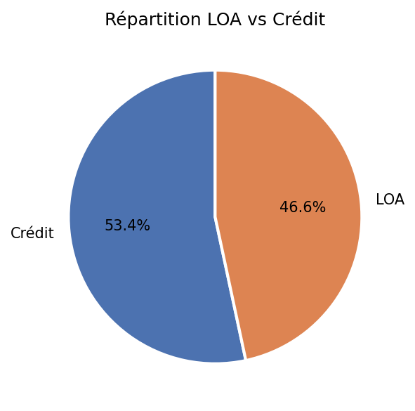

La répartition entre **crédit** et **LOA** met en évidence une structuration relativement équilibrée du recours au financement. Cela confirme que ce dernier constitue une composante essentielle de l’acte d’achat pour une partie importante de la clientèle.

## 9.2 Financement et mode de livraison par segment

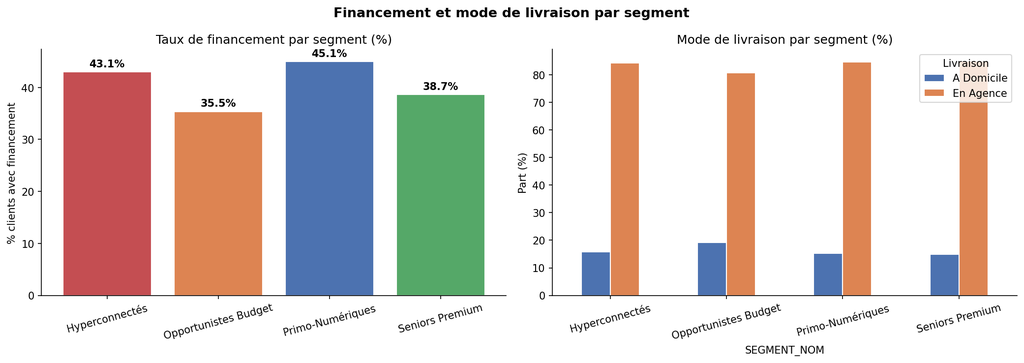

Les écarts entre segments sont instructifs. Certains profils, notamment les **Primo-Numériques**, recourent davantage au financement. Par ailleurs, la livraison en agence reste globalement majoritaire, ce qui montre que l’expérience physique conserve un rôle important, même dans un parcours fortement digitalisé.

Le financement n’est pas seulement un service complémentaire : il agit comme un outil de conversion, particulièrement pertinent pour les segments intermédiaires ou plus sensibles à l’effort mensuel. De même, la livraison peut devenir un levier de différenciation selon le profil client.

# 10 Benchmark marché : Aramisauto face au marché national

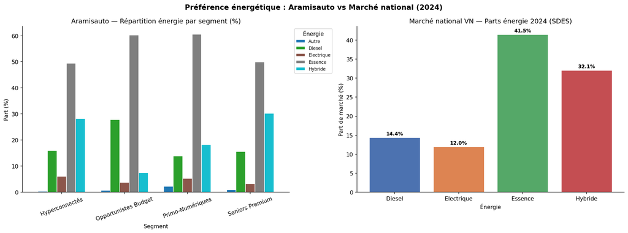

Cependant, cette comparaison révèle aussi une opportunité : l’**hybride** apparaît comme un axe de développement crédible, notamment pour des profils premium recherchant une transition énergétique sans rupture forte d’usage.

# 11 Commandes, prix et proximité agence

## 11.1 Commandes et distribution des prix

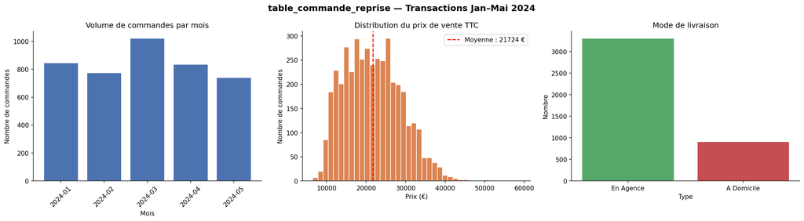

Le volume des commandes sur janvier à mai 2024 montre une activité relativement soutenue avec un pic en mars. La distribution des prix confirme un cœur de marché situé autour du milieu de gamme, ce qui correspond bien au panier moyen observé dans les KPIs globaux.

## 11.2 Distance et durée vers l’agence

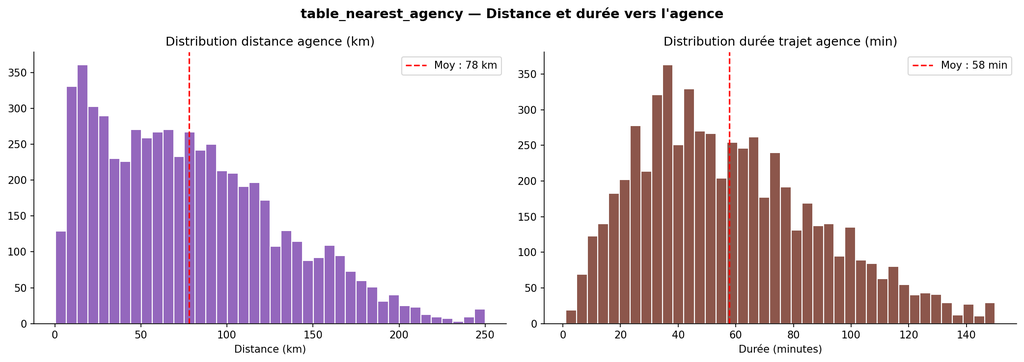

La distance à l’agence et le temps de trajet constituent des variables importantes dans la compréhension du parcours client. Elles peuvent influencer le choix entre passage en agence, accompagnement à distance et livraison à domicile. La dispersion observée suggère que cette variable mérite une prise en compte concrète dans la personnalisation des parcours commerciaux.

# 12 Recommandations marketing

## 12.1 Seniors Premium

Pour ce segment, les recommandations principales sont les suivantes :

- renforcer la relation de confiance ;
- proposer un accompagnement humain plus premium ;
- valoriser les garanties, la qualité du véhicule et la sérénité d’achat ;
- développer des parcours plus personnalisés, y compris sur la livraison.

## 12.2 Opportunistes Budget

Pour ce segment, il convient de :

- mettre en avant les bons plans et les véhicules à fort rapport qualité/prix ;
- renforcer la transparence sur l’état du véhicule ;
- proposer des alertes prix ;
- rendre les options de financement plus visibles.

## 12.3 Primo-Numériques

Pour ce segment, les pistes prioritaires sont :

- mettre en avant les simulateurs de financement ;
- valoriser les véhicules récents à faible kilométrage ;
- automatiser les relances post-visite ;
- travailler une logique d’upsell.

## 12.4 Hyperconnectés

Pour ce segment, il est pertinent de :

- activer des campagnes de remarketing personnalisées ;
- enrichir les fiches produits avec des contenus détaillés ;
- proposer des outils d’aide à la décision ;
- faciliter les interactions rapides : chat, call-back, rappel.

La segmentation n’a de valeur que si elle est activable. Ici, elle débouche sur des recommandations différenciées selon la valeur, la sensibilité prix, le rapport au digital et le recours au financement. Elle peut donc directement alimenter une stratégie CRM, média ou produit.

# 13 Présentation de l’application

L’étude a été restituée via une application analytique organisée en plusieurs pages :

- **Vue d’ensemble**
- **Segmentation**
- **Catalogue**
- **Géographie**
- **Benchmark**
- **Recommandations**

Cette application permet une lecture interactive des résultats et facilite leur appropriation par des utilisateurs non techniques.

# 14 Conclusion

Ce projet a permis de construire une lecture structurée et actionnable du portefeuille client Aramisauto. L’analyse descriptive, l’enrichissement externe et la segmentation K-means convergent vers une conclusion forte : la clientèle Aramisauto n’est pas homogène, mais organisée autour de quatre grands profils aux comportements distincts.

Le segment **Seniors Premium** constitue le cœur de valeur. Les **Opportunistes Budget** soutiennent fortement le volume. Les **Primo-Numériques** présentent un fort potentiel commercial via le financement. Enfin, les **Hyperconnectés** représentent une cible stratégique pour les actions digitales fines.

Au-delà des profils eux-mêmes, cette étude montre que la compréhension du client passe par un croisement entre :

- données transactionnelles,
- comportement digital,
- produit acheté,
- environnement géographique,
- et contexte de marché.

C’est cette articulation qui permet de passer d’une simple description statistique à une véritable lecture business du portefeuille.

# 15 Annexes

## 15.1 Variables utilisées pour la segmentation

Les variables principales utilisées pour le clustering sont les suivantes :

- `AGE`
- `PRIX_VENTE_TTC_COM`
- `VEHICULE_KM`
- `VEHICULE_AGE_ANNEES`
- `NB_SESSIONS`
- `NB_PAGES_PRODUIT`
- `NB_PAGES_SEARCH`
- `AGENCE_DIST_KM`
- `A_REPRISE`
- `A_FINANCEMENT`
- `IS_MALE`
- `REVENU_MEDIAN_UC_2021`

## 15.2 Figures mobilisées dans le rapport

| Figures |
| --- |
| fig_vehicule.png |
| fig_client_profil.png |
| fig_navigation.png |
| fig_kmeans_selection_k.png |
| fig_kmeans_clusters_pca.png |
| fig_radar_segments.png |
| fig_geo_segments.png |
| fig_financement.png |
| fig_financement_livraison.png |
| fig_energie_benchmark.png |
| fig_commande_reprise.png |
| fig_agency.png |

## 15.3 Sources externes

- INSEE Filosofi 2021
- INSEE populations légales 2021
- SDES — Immatriculations de véhicules routiers